# A3: SPL Library Checkouts

### Introduction

I have included three charts that shows trends of people’s preference over the type of books including, Ebooks, printed books, and sound disc. The reason why I chose these three material types is that I thought the comparison of the three materials are going to show us the changing trend in each material type and the overall trends.

### Summary Information

- What is the average number of checkouts for each item? The average number of checkouts for each item (4 values total):

EBOOK: 3.403392 BOOK: 2.847207 AUDIOBOOK: 4.761147 SOUNDDISC: 1.596941

2022.1 -2.965044 2022.2 - 2.74244 2022.3 - 2.911105 2022.4 - 2.805779 2022.5 - 2.828401 2022.6 - 2.905877 2022.7 - 2.787964 2022.8 - 2.904679 2022.9 - 2.808679 2022.10 - 2.84046 2022.11 - 2.818921 2022.12 - 2.694061 2023.1 - 2.965565

### The Dataset

- Who collected/published the data? The Seattle Public Library
- What are the parameters of the data (dates, number of checkouts, kinds of books, etc.)? Months, Year, Usage Class, Checkout type, Material type, number of checkouts, Book Title, ISBN, Creator, Subjects, Publisher, Publication Year
- How was the data collected or generated? The data is collecteed by using The Socrata Open Data API and it allows you to programmatically access a wealth of open data resources from governments, non-profits, and NGOs around the world.
- Why was the data collected?  
  For the purpose of increasing the quality of life for our residents; increasing transparency, accountability and comparability; promoting economic development and research; and improving internal performance management.
- What, if any, ethical questions do you need to consider when working with this data? I wonder the location of Seattle Public Libraries and want to know whether it is easy for everyone to access so that the result of data is equally collected.
- What are possible limitations or problems with this data? (at least 200 words) One of the possible limitations from this data are who did they collected the data from. Although Seattle Public Libraries are located in various location in Seattle, it is unclear that location of the libraries is easily approachable to everyone. In my personal experience, the public library was located in Wedgwood area where the age range is higher and majority of the visitors are white. If this is the case, we are not analyzing the data and cannot draw conclusions that can be applied to every sector of people in Seattle Area. Furthermore, since the age range of the neighborhood is higher than other neighborhoods, the data cannot be collected from all of the age ranges. This dataset might not represent the holistic view and type of people who got collected from the Seattle Public Library. Lastly, in order to figure the trend of checkouts in Material Type can be limited because there are so many people who purchase books from Amazon and other online based bookstores. This may also lay different results from other data collection which means that the data set from Seattle Public Library does not represent the current trend of book preferences and other possible trends.

### First Trends Over Time Chart

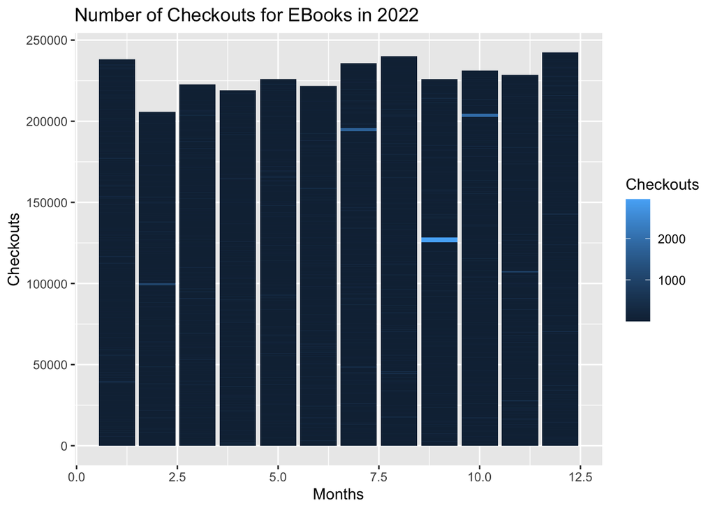

### Second Trends Over Time Chart

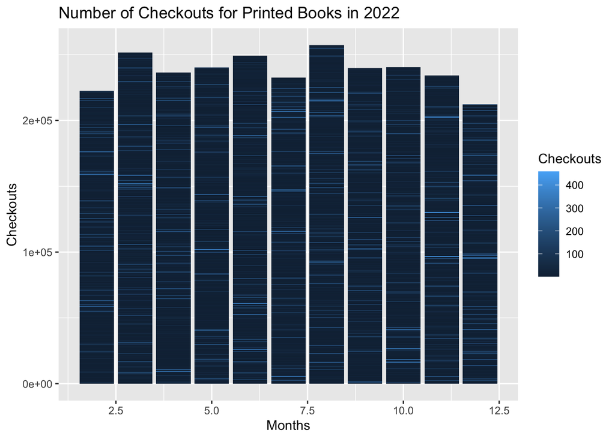

### Your Choice

[figure not shown]